# Sleep Summary Stats Comparison

Megan McMahon

3/12/2021

```r
data_dir <- '~/Box/CogNeuroLab/Wearables/data/'
fit <- read_csv(paste0(data_dir, 'fitbit/fitbitSleepStatsGroup.csv'))
act <- read_csv(paste0(data_dir, 'actiwatch/wa_act_combined.csv'))
act_cl <- read_csv(paste0(data_dir, 'actiwatch/actiware_manual_clean/wa_act_combined.csv'))

df_cx <- readr::read_csv(paste0(data_dir, 'df_main.csv'))

head(act)
```

| analysis_name | subject_id | data_start_date | data_start_time | interval_type | interval_number | start_date | start_time | end_date | end_time | duration | off_wrist | percent_off_wrist | total_ac | percent_invalid_sw | onset_latency | efficiency | wake_time | percent_wake | sleep_time | percent_sleep | percent_immobile | fragmentation | number_of_scores | number_of_manual | number_of_scheduled | number_of_no_responses | avg_score | avg_manual | avg_scheduled | … |
| --- | --- | --- | --- | --- | --- | --- | --- | --- | --- | --- | --- | --- | --- | --- | --- | --- | --- | --- | --- | --- | --- | --- | --- | --- | --- | --- | --- | --- | --- | --- |
| New Analysis | 10011 | 10/24/2019 | 16:30:00 | REST | 1 | 10/24/2019 | 8:50:00 PM | 10/25/2019 | 6:07:30 AM | 557.5 | NaN | NaN | 12945 | 0 | NaN | NaN | 78.0 | 13.99 | 479.5 | 86.01 | 88.88 | 14.76 | NaN | NaN | NaN | NaN | NaN | NaN | NaN | … |
| New Analysis | 10011 | 10/24/2019 | 16:30:00 | REST | 2 | 10/25/2019 | 10:38:30 PM | 10/26/2019 | 6:53:00 AM | 494.5 | NaN | NaN | 9450 | 0 | NaN | NaN | 51.0 | 10.31 | 443.5 | 89.69 | 92.62 | 7.38 | NaN | NaN | NaN | NaN | NaN | NaN | NaN | … |
| New Analysis | 10011 | 10/24/2019 | 16:30:00 | REST | 3 | 10/26/2019 | 9:58:30 PM | 10/27/2019 | 7:10:00 AM | 551.5 | NaN | NaN | 6720 | 0 | NaN | NaN | 45.5 | 8.25 | 506.0 | 91.75 | 93.11 | 18.25 | NaN | NaN | NaN | NaN | NaN | NaN | NaN | … |
| New Analysis | 10011 | 10/24/2019 | 16:30:00 | REST | 4 | 10/28/2019 | 12:09:30 AM | 10/28/2019 | 5:58:00 AM | 348.5 | NaN | NaN | 6779 | 0 | NaN | NaN | 34.0 | 9.76 | 314.5 | 90.24 | 90.96 | 15.71 | NaN | NaN | NaN | NaN | NaN | NaN | NaN | … |
| New Analysis | 10011 | 10/24/2019 | 16:30:00 | REST | 5 | 10/28/2019 | 11:22:00 PM | 10/29/2019 | 6:02:30 AM | 400.5 | NaN | NaN | 5906 | 0 | NaN | NaN | 33.5 | 8.36 | 367.0 | 91.64 | 92.63 | 10.94 | NaN | NaN | NaN | NaN | NaN | NaN | NaN | … |
| New Analysis | 10011 | 10/24/2019 | 16:30:00 | REST | 6 | 10/29/2019 | 9:52:00 PM | 10/30/2019 | 6:54:00 AM | 542.0 | NaN | NaN | 10823 | 0 | NaN | NaN | 62.0 | 11.44 | 480.0 | 88.56 | 91.05 | 14.83 | NaN | NaN | NaN | NaN | NaN | NaN | NaN | … |

```r
#clean actiware datasets

clean_actiware_combined_df <- function(df) {
  TimeInBed <- df %>%
  filter(interval_type == 'REST') %>%
  select(subject_id, start_date, duration)

dfnew <- df %>%
  filter(interval_type == 'SLEEP') %>%
  merge(TimeInBed, by = c('subject_id', 'start_date')) %>%
  rename(time_in_bed = duration.y, time_asleep = duration.x) %>%
  select(-X31, -(number_of_scores:avg_scheduled), -interval_type, -interval_number) %>%
  mutate(date = format(lubridate::round_date(lubridate::parse_date_time(paste0(start_date, ' ', start_time), '%m/%d/%Y %I:%M:%S %p'), unit = 'd'), '%Y-%m-%d'),
         joinid = paste0(subject_id, '_', date))

return(dfnew)
}

act <- clean_actiware_combined_df(act)
act_cl <- clean_actiware_combined_df(act_cl)
head(act)
```

|  | subject_id | start_date | analysis_name | data_start_date | data_start_time | start_time | end_date | end_time | time_asleep | off_wrist | percent_off_wrist | total_ac | percent_invalid_sw | onset_latency | efficiency | wake_time | percent_wake | sleep_time | percent_sleep | percent_immobile | fragmentation | time_in_bed | date | joinid |
| --- | --- | --- | --- | --- | --- | --- | --- | --- | --- | --- | --- | --- | --- | --- | --- | --- | --- | --- | --- | --- | --- | --- | --- | --- |
| 1 | 10011 | 10/24/2019 | New Analysis | 10/24/2019 | 16:30:00 | 8:55:00 PM | 10/25/2019 | 6:07:00 AM | 552.0 | NaN | NaN | 12923 | 0 | 5.0 | 85.02 | 78.0 | 14.13 | 474.0 | 85.87 | 89.13 | 14.57 | 557.5 | 2019-10-25 | 10011_2019-10-25 |
| 2 | 10011 | 10/25/2019 | New Analysis | 10/24/2019 | 16:30:00 | 10:42:30 PM | 10/26/2019 | 6:44:30 AM | 482.0 | NaN | NaN | 8935 | 0 | 4.0 | 88.07 | 46.5 | 9.65 | 435.5 | 90.35 | 92.95 | 7.05 | 494.5 | 2019-10-26 | 10011_2019-10-26 |
| 3 | 10011 | 10/26/2019 | New Analysis | 10/24/2019 | 16:30:00 | 10:11:00 PM | 10/27/2019 | 7:09:30 AM | 538.5 | NaN | NaN | 6240 | 0 | 12.5 | 89.85 | 43.0 | 7.99 | 495.5 | 92.01 | 93.59 | 18.31 | 551.5 | 2019-10-27 | 10011_2019-10-27 |
| 4 | 10011 | 10/28/2019 | New Analysis | 10/24/2019 | 16:30:00 | 11:29:00 PM | 10/29/2019 | 6:02:00 AM | 393.0 | NaN | NaN | 4410 | 0 | 7.0 | 90.51 | 30.5 | 7.76 | 362.5 | 92.24 | 93.26 | 6.74 | 400.5 | 2019-10-29 | 10011_2019-10-29 |
| 5 | 10011 | 10/28/2019 | New Analysis | 10/24/2019 | 16:30:00 | 11:29:00 PM | 10/29/2019 | 6:02:00 AM | 393.0 | NaN | NaN | 4410 | 0 | 7.0 | 90.51 | 30.5 | 7.76 | 362.5 | 92.24 | 93.26 | 6.74 | 348.5 | 2019-10-29 | 10011_2019-10-29 |
| 6 | 10011 | 10/28/2019 | New Analysis | 10/24/2019 | 16:30:00 | 12:17:30 AM | 10/28/2019 | 5:57:30 AM | 340.0 | NaN | NaN | 4911 | 0 | 8.0 | 89.96 | 26.5 | 7.79 | 313.5 | 92.21 | 92.35 | 14.79 | 400.5 | 2019-10-28 | 10011_2019-10-28 |

```r
#fitbit subject numbers are different for subjects who used Beiwe, so need to match them with their full subject number from Actiware
match_subject_number <- function(data, pad_digits, match_to){
    for (i in unique(data$subject[data$subject < 10000])){
    subno <- data$subject[grep(paste0('[1-2]', stringr::str_pad(i, pad_digits, side = 'left', pad = '0')), match_to)][1]
    if (! is.na(subno)){
      data$subject[data$subject == i] <- subno
    }
    }
  return(data)
}
fit <- match_subject_number(fit, 4, act$subject_id)
head(fit)
```

| X1 | TotalMinutesAsleep | TotalTimeInBed | subject | date | StartTime | Duration | Efficiency | MinutesAfterWakeup | MinutesAsleep | MinutesToFallAsleep | TimeInBed | AwakeCount | AwakeDuration | RestlessCount | RestlessDuration |
| --- | --- | --- | --- | --- | --- | --- | --- | --- | --- | --- | --- | --- | --- | --- | --- |
| 0 | 508 | 556 | 10011 | 2019-10-25 | 10/24/2019 8:51:00 PM | 33360000 | 91 | 0 | 508 | 0 | 556 | 2 | 4 | 8 | 23 |
| 1 | 450 | 488 | 10011 | 2019-11-04 | 11/3/2019 9:57:30 PM | 29280000 | 92 | 0 | 450 | 0 | 488 | 3 | 3 | 21 | 35 |
| 2 | 480 | 544 | 10011 | 2019-11-05 | 11/4/2019 9:04:30 PM | 32640000 | 88 | 0 | 480 | 0 | 544 | 6 | 10 | 27 | 54 |
| 3 | 405 | 429 | 10011 | 2019-11-06 | 11/5/2019 10:41:30 PM | 25740000 | 94 | 0 | 405 | 0 | 429 | 2 | 2 | 11 | 22 |
| 4 | 373 | 404 | 10011 | 2019-11-07 | 11/6/2019 11:17:00 PM | 24240000 | 93 | 2 | 373 | 0 | 404 | 2 | 8 | 13 | 23 |
| 5 | 677 | 708 | 10012 | 2019-10-19 | 10/19/2019 1:55:00 AM | 35640000 | 95 | 0 | 564 | 0 | 594 | 2 | 6 | 13 | 24 |

```r
# match date formats between fitbit and actiwatch datasets
act_cl <- act_cl %>%
  mutate(cleaned = ifelse(analysis_name == "Manual", 1, 0))

actall <- act %>%
  merge(act_cl, by = c('joinid', 'subject_id', 'date'), suffixes = c('_act', '_cl'))

head(actall)
```

|  | joinid | subject_id | date | start_date_act | analysis_name_act | data_start_date_act | data_start_time_act | start_time_act | end_date_act | end_time_act | time_asleep_act | off_wrist_act | percent_off_wrist_act | total_ac_act | percent_invalid_sw_act | onset_latency_act | efficiency_act | wake_time_act | percent_wake_act | sleep_time_act | percent_sleep_act | percent_immobile_act | fragmentation_act | time_in_bed_act | start_date_cl | analysis_name_cl | data_start_date_cl | data_start_time_cl | start_time_cl | … |
| --- | --- | --- | --- | --- | --- | --- | --- | --- | --- | --- | --- | --- | --- | --- | --- | --- | --- | --- | --- | --- | --- | --- | --- | --- | --- | --- | --- | --- | --- | --- |
| 1 | 10011_2019-10-25 | 10011 | 2019-10-25 | 10/24/2019 | New Analysis | 10/24/2019 | 16:30:00 | 8:55:00 PM | 10/25/2019 | 6:07:00 AM | 552.0 | NaN | NaN | 12923 | 0 | 5.0 | 85.02 | 78.0 | 14.13 | 474.0 | 85.87 | 89.13 | 14.57 | 557.5 | 10/24/2019 | New Analysis | 10/24/2019 | 16:30:00 | 8:55:00 PM | … |
| 2 | 10011_2019-10-26 | 10011 | 2019-10-26 | 10/25/2019 | New Analysis | 10/24/2019 | 16:30:00 | 10:42:30 PM | 10/26/2019 | 6:44:30 AM | 482.0 | NaN | NaN | 8935 | 0 | 4.0 | 88.07 | 46.5 | 9.65 | 435.5 | 90.35 | 92.95 | 7.05 | 494.5 | 10/25/2019 | New Analysis | 10/24/2019 | 16:30:00 | 10:42:30 PM | … |
| 3 | 10011_2019-10-27 | 10011 | 2019-10-27 | 10/26/2019 | New Analysis | 10/24/2019 | 16:30:00 | 10:11:00 PM | 10/27/2019 | 7:09:30 AM | 538.5 | NaN | NaN | 6240 | 0 | 12.5 | 89.85 | 43.0 | 7.99 | 495.5 | 92.01 | 93.59 | 18.31 | 551.5 | 10/26/2019 | New Analysis | 10/24/2019 | 16:30:00 | 10:11:00 PM | … |
| 4 | 10011_2019-10-28 | 10011 | 2019-10-28 | 10/28/2019 | New Analysis | 10/24/2019 | 16:30:00 | 12:17:30 AM | 10/28/2019 | 5:57:30 AM | 340.0 | NaN | NaN | 4911 | 0 | 8.0 | 89.96 | 26.5 | 7.79 | 313.5 | 92.21 | 92.35 | 14.79 | 348.5 | 10/28/2019 | New Analysis | 10/24/2019 | 16:30:00 | 12:17:30 AM | … |
| 5 | 10011_2019-10-28 | 10011 | 2019-10-28 | 10/28/2019 | New Analysis | 10/24/2019 | 16:30:00 | 12:17:30 AM | 10/28/2019 | 5:57:30 AM | 340.0 | NaN | NaN | 4911 | 0 | 8.0 | 89.96 | 26.5 | 7.79 | 313.5 | 92.21 | 92.35 | 14.79 | 348.5 | 10/28/2019 | New Analysis | 10/24/2019 | 16:30:00 | 12:17:30 AM | … |
| 6 | 10011_2019-10-28 | 10011 | 2019-10-28 | 10/28/2019 | New Analysis | 10/24/2019 | 16:30:00 | 12:17:30 AM | 10/28/2019 | 5:57:30 AM | 340.0 | NaN | NaN | 4911 | 0 | 8.0 | 89.96 | 26.5 | 7.79 | 313.5 | 92.21 | 92.35 | 14.79 | 400.5 | 10/28/2019 | New Analysis | 10/24/2019 | 16:30:00 | 12:17:30 AM | … |

```r
fitnew <- fit %>%
  mutate(date = format(lubridate::parse_date_time(StartTime, '%m/%d/%Y %I:%M:%S %p'), format = '%Y-%m-%d'),
         joinid = paste0(subject, '_', format(date, format = '%Y-%m-%d'))) %>%
  rename(time_asleep = TotalMinutesAsleep, time_in_bed = TotalTimeInBed, start_time = StartTime, efficiency = Efficiency, min_after_wake = MinutesAfterWakeup, onset_latency = MinutesToFallAsleep, awake_count = AwakeCount, awake_duration = AwakeDuration, restless_count = RestlessCount, restless_duration = RestlessDuration) %>%
  select(-X1, -Duration, -MinutesAsleep, -TimeInBed) %>%
  rename_at(vars(-subject, -date, -joinid), ~ paste0(., '_fit'))

head(fitnew)
```

| time_asleep_fit | time_in_bed_fit | subject | date | start_time_fit | efficiency_fit | min_after_wake_fit | onset_latency_fit | awake_count_fit | awake_duration_fit | restless_count_fit | restless_duration_fit | joinid |
| --- | --- | --- | --- | --- | --- | --- | --- | --- | --- | --- | --- | --- |
| 508 | 556 | 10011 | 2019-10-24 | 10/24/2019 8:51:00 PM | 91 | 0 | 0 | 2 | 4 | 8 | 23 | 10011_2019-10-24 |
| 450 | 488 | 10011 | 2019-11-03 | 11/3/2019 9:57:30 PM | 92 | 0 | 0 | 3 | 3 | 21 | 35 | 10011_2019-11-03 |
| 480 | 544 | 10011 | 2019-11-04 | 11/4/2019 9:04:30 PM | 88 | 0 | 0 | 6 | 10 | 27 | 54 | 10011_2019-11-04 |
| 405 | 429 | 10011 | 2019-11-05 | 11/5/2019 10:41:30 PM | 94 | 0 | 0 | 2 | 2 | 11 | 22 | 10011_2019-11-05 |
| 373 | 404 | 10011 | 2019-11-06 | 11/6/2019 11:17:00 PM | 93 | 2 | 0 | 2 | 8 | 13 | 23 | 10011_2019-11-06 |
| 677 | 708 | 10012 | 2019-10-19 | 10/19/2019 1:55:00 AM | 95 | 0 | 0 | 2 | 6 | 13 | 24 | 10012_2019-10-19 |

```r
df <- merge(actall, fitnew, by = 'joinid')

write_csv(df, paste0(data_dir, 'sleep-summary_act-auto_act-cl_fitbit.csv'))

df %>%
  select(subject, matches('time_asleep')) %>%
  head()
```

|  | subject | time_asleep_act | time_asleep_cl | time_asleep_fit |
| --- | --- | --- | --- | --- |
| 1 | 10011 | 566.5 | 566.5 | 450 |
| 2 | 10011 | 464.0 | 464.0 | 480 |
| 3 | 10011 | 532.5 | 532.5 | 405 |
| 4 | 10011 | 402.5 | 402.5 | 373 |
| 5 | 10012 | 590.0 | 590.0 | 527 |
| 6 | 10012 | 590.0 | 590.0 | 677 |

```r
NA
```

```r
df <- merge(df, df_cx, by = 'subject')
```

```r
df_cx %>%
  mutate(age_group = recode(age_group, "Young Adults", "Older Adults")) %>%
  mutate(handedness = recode(handedness, "Left", "Right", "Both")) %>%
  mutate(actiwatch_arm = recode(actiwatch_arm, "Left", "Right")) %>%
  mutate(dominant = ifelse(handedness == actiwatch_arm, 1, 0)) %>%
  group_by(age_group, dominant) %>%
  summarise(n = n())
```

| age_group | dominant | n |
| --- | --- | --- |
| Older Adults | 0 | 12 |
| Older Adults | 1 | 14 |
| Young Adults | 0 | 16 |
| Young Adults | 1 | 14 |

```r
df_cx %>%
  mutate(age_group = recode(age_group, "Young Adults", "Older Adults")) %>%
  mutate(handedness = recode(handedness, "Left", "Right", "Both")) %>%
  mutate(actiwatch_arm = recode(actiwatch_arm, "Left", "Right")) %>%
  filter(handedness == "Right") %>%
  mutate(dominant = ifelse(handedness == actiwatch_arm, 1, 0)) %>%
  group_by(age_group, dominant) %>%
  summarise(n = n())
```

| age_group | dominant | n |
| --- | --- | --- |
| Older Adults | 0 | 11 |
| Older Adults | 1 | 12 |
| Young Adults | 0 | 14 |
| Young Adults | 1 | 13 |

```r
df_cx %>%
  mutate(age_group = recode(age_group, "Young Adults", "Older Adults")) %>%
  mutate(handedness = recode(handedness, "Left", "Right", "Both")) %>%
  mutate(actiwatch_arm = recode(actiwatch_arm, "Left", "Right")) %>%
  filter(handedness == "Left") %>%
  mutate(dominant = ifelse(handedness == actiwatch_arm, 1, 0)) %>%
  group_by(age_group, dominant) %>%
  summarise(n = n())
```

| age_group | dominant | n |
| --- | --- | --- |
| Older Adults | 1 | 2 |
| Young Adults | 0 | 2 |
| Young Adults | 1 | 1 |

```r
exclude = c('10023', '10076', '20182', '20184', '20176', '10151', '10139')
df <- df[!df$subject %in% exclude, ]

df_means <- df %>%
  select(subject_id, analysis_name_cl, where(is.numeric)) %>%
  group_by(subject, analysis_name_cl) %>%
  summarise(across(where(is.numeric), ~ mean(.x, na.rm = TRUE)))

head(df_means)
```

| subject | analysis_name_cl | subject_id | time_asleep_act | off_wrist_act | percent_off_wrist_act | total_ac_act | percent_invalid_sw_act | onset_latency_act | efficiency_act | wake_time_act | percent_wake_act | sleep_time_act | percent_sleep_act | percent_immobile_act | fragmentation_act | time_in_bed_act | time_asleep_cl | off_wrist_cl | percent_off_wrist_cl | total_ac_cl | percent_invalid_sw_cl | onset_latency_cl | efficiency_cl | wake_time_cl | percent_wake_cl | sleep_time_cl | percent_sleep_cl | percent_immobile_cl | fragmentation_cl | … |
| --- | --- | --- | --- | --- | --- | --- | --- | --- | --- | --- | --- | --- | --- | --- | --- | --- | --- | --- | --- | --- | --- | --- | --- | --- | --- | --- | --- | --- | --- | --- |
| 10011 | New Analysis | 10011 | 491.3750 | NaN | NaN | 6949.750 | 0 | 14.000000 | 86.73000 | 46.12500 | 9.495000 | 445.2500 | 90.50500 | 92.41250 | 15.61500 | 511.8750 | 491.3750 | NaN | NaN | 6949.750 | 0 | 14.000000 | 86.73000 | 46.12500 | 9.495000 | 445.2500 | 90.50500 | 92.41250 | 15.61500 | … |
| 10012 | Manual | 10012 | 481.6818 | NaN | NaN | 6227.182 | 0 | 15.727273 | 85.94545 | 44.59091 | 9.057273 | 437.0909 | 90.94273 | 89.11455 | 19.34636 | 571.0000 | 481.6818 | NaN | NaN | 6227.182 | 0 | 14.227273 | 86.62000 | 44.59091 | 9.057273 | 437.0909 | 90.94273 | 89.11455 | 19.34636 | … |
| 10014 | Manual | 10014 | 509.0690 | NaN | NaN | 8327.276 | 0 | 6.068966 | 86.01103 | 45.17241 | 8.794483 | 463.8966 | 91.20552 | 90.13621 | 21.16483 | 541.6207 | 509.0690 | NaN | NaN | 8327.276 | 0 | 6.068966 | 86.01103 | 45.17241 | 8.794483 | 463.8966 | 91.20552 | 90.13621 | 21.16483 | … |
| 10016 | New Analysis | 10016 | 459.9194 | NaN | NaN | 12928.742 | 0 | 4.338710 | 80.88194 | 71.66129 | 15.461613 | 388.2581 | 84.53839 | 82.63677 | 24.59419 | 461.0968 | 459.9194 | NaN | NaN | 12928.742 | 0 | 4.338710 | 80.88194 | 71.66129 | 15.461613 | 388.2581 | 84.53839 | 82.63677 | 24.59419 | … |
| 10024 | New Analysis | 10024 | 422.7812 | NaN | NaN | 6792.812 | 0 | 8.843750 | 83.70375 | 48.00000 | 11.393125 | 374.7812 | 88.60688 | 89.16250 | 22.67063 | 442.0312 | 422.7812 | NaN | NaN | 6792.812 | 0 | 8.843750 | 83.70375 | 48.00000 | 11.393125 | 374.7812 | 88.60688 | 89.16250 | 22.67063 | … |
| 10025 | New Analysis | 10025 | 458.3000 | NaN | NaN | 7133.800 | 0 | 17.333333 | 82.68867 | 52.36667 | 11.302000 | 405.9333 | 88.69800 | 89.15200 | 20.02667 | 491.5000 | 458.3000 | NaN | NaN | 7133.800 | 0 | 17.333333 | 82.68867 | 52.36667 | 11.302000 | 405.9333 | 88.69800 | 89.15200 | 20.02667 | … |

```r
NA
```

## Correlations

```r
library(corrr)
library(purrr)
library(dplyr)

df %>%
  group_by(subject) %>%
  select(where(is.numeric)) %>%
  group_by(subject) %>%
  summarise_at(vars(-subject_id), funs(mean(., na.rm=TRUE))) %>%
  corrr::correlate(method = 'spearman') %>%
  corrr::focus(matches('time_asleep'), mirror = TRUE)
```

| term | time_asleep_act | time_asleep_cl | time_asleep_fit |
| --- | --- | --- | --- |
| time_asleep_act | NA | 0.9750322 | 0.3338481 |
| time_asleep_cl | 0.9750322 | NA | 0.3637066 |
| time_asleep_fit | 0.3338481 | 0.3637066 | NA |

```r
NA
```

```r
df %>%
  group_by(subject) %>%
  filter(handedness == 2) %>%
  select(where(is.numeric)) %>%
  group_by(subject) %>%
  summarise_at(vars(-subject_id), funs(mean(., na.rm=TRUE))) %>%
  corrr::correlate(method = 'spearman') %>%
  corrr::focus(matches('time_asleep'), mirror = TRUE)
```

| term | time_asleep_act | time_asleep_cl | time_asleep_fit |
| --- | --- | --- | --- |
| time_asleep_act | NA | 0.9719251 | 0.2884358 |
| time_asleep_cl | 0.9719251 | NA | 0.3275401 |
| time_asleep_fit | 0.2884358 | 0.3275401 | NA |

```r
df %>% #all
  group_by(subject) %>%
  select(where(is.numeric)) %>%
  group_by(subject) %>%
  summarise_at(vars(-subject_id), funs(mean(., na.rm=TRUE))) %>%
  corrr::correlate(method = 'spearman') %>%
  corrr::focus(matches('bed'), mirror = TRUE)
```

| term | time_in_bed_act | time_in_bed_cl | time_in_bed_fit |
| --- | --- | --- | --- |
| time_in_bed_act | NA | 0.8890605 | 0.2223938 |
| time_in_bed_cl | 0.8890605 | NA | 0.3333333 |
| time_in_bed_fit | 0.2223938 | 0.3333333 | NA |

```r
df %>% #right handed only
  group_by(subject) %>%
  filter(handedness == 2) %>%
  select(where(is.numeric)) %>%
  group_by(subject) %>%
  summarise_at(vars(-subject_id), funs(mean(., na.rm=TRUE))) %>%
  corrr::correlate(method = 'spearman') %>%
  corrr::focus(matches('bed'), mirror = TRUE)
```

| term | time_in_bed_act | time_in_bed_cl | time_in_bed_fit |
| --- | --- | --- | --- |
| time_in_bed_act | NA | 0.8773396 | 0.1517380 |
| time_in_bed_cl | 0.8773396 | NA | 0.2774064 |
| time_in_bed_fit | 0.1517380 | 0.2774064 | NA |

```r
NA
```

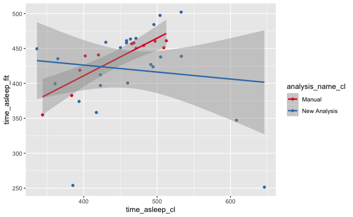

```r
library(RColorBrewer)

df_means %>%
  ggplot(aes(x = time_asleep_cl, y = time_asleep_fit, color = analysis_name_cl)) +
  geom_point() +
  stat_smooth(method = 'lm') +
  scale_color_brewer(palette = 'Set1')
```

```r
NA
NA
```

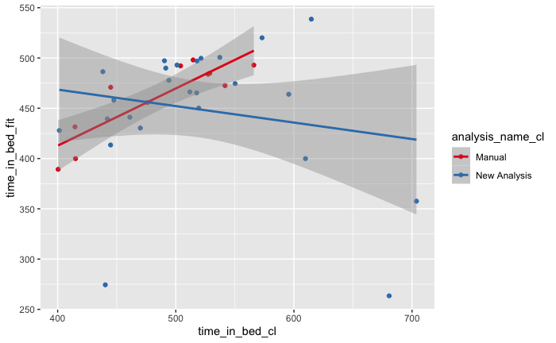

```r
df_means %>%
  ggplot(aes(x = time_in_bed_cl, y = time_in_bed_fit, color = analysis_name_cl)) +
  geom_point() +
  stat_smooth(method = 'lm') +
  scale_color_brewer(palette = 'Set1')
```

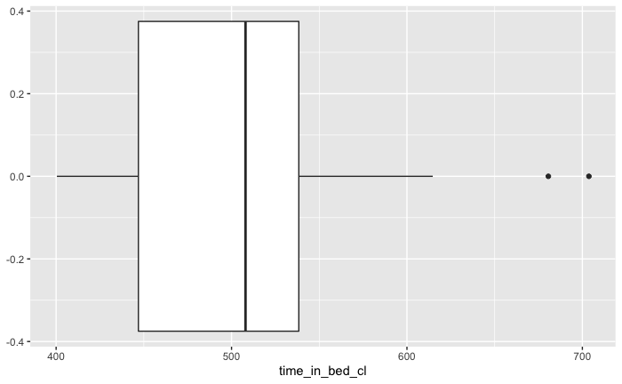

```r
# excluded subject 10139
df_means %>%
  ggplot(aes(x = time_in_bed_cl)) +
  geom_boxplot()
```

```r
df_means$subject[df_means$time_in_bed_cl > 700]
```

```
[1] 20108
```

### Repeated measures correlations

[Documentation](https://cran.r-project.org/web/packages/rmcorr/rmcorr.pdf)

[Repeated Measures Correlation, Bakdash1 and Marusich, 2017](https://www.frontiersin.org/articles/10.3389/fpsyg.2017.00456/full)

#### Time in Bed

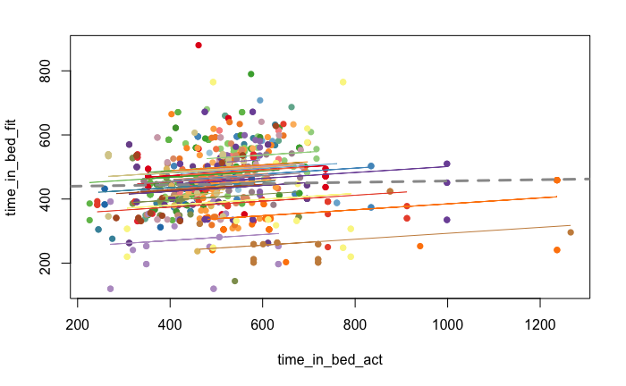

```r
library(rmcorr)

colourCount = length(unique(df$subject))
getPalette = colorRampPalette(brewer.pal(9, "Spectral"))

my.rmc <- rmcorr(participant = subject, measure1 = time_in_bed_act, measure2 = time_in_bed_fit, dataset = df)
plot(my.rmc, overall = TRUE)
```

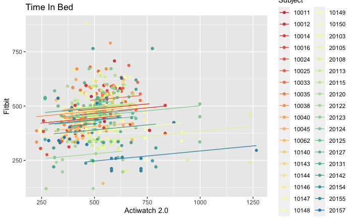

```r
ggplot2::ggplot(df, ggplot2::aes(x = time_in_bed_act, y = time_in_bed_fit, group = factor(subject),
      color = factor(subject))) +
      ggplot2::geom_point(ggplot2::aes(colour = factor(subject))) +
      ggplot2::geom_line(ggplot2::aes(y = my.rmc$model$fitted.values), linetype = 1) + xlab('Actiwatch 2.0') + ylab('Fitbit') + ggtitle('Time In Bed') + scale_color_manual(values = getPalette(colourCount)) + labs(color = 'Subject') + ggsave(paste0(data_dir, 'CARE2021/figures/timeinbedrmcorr.png'), height = 5, width = 8, dpi = 300)
```

#### Time in Bed: Cleaned Actiwatch data

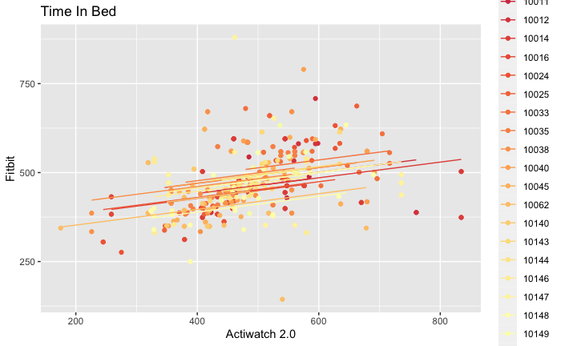

```r
my.rmc <- rmcorr(participant = subject, measure1 = time_in_bed_cl, measure2 = time_in_bed_fit, dataset = df[df$age_group == 1,])

ggplot2::ggplot(df[df$age_group == 1,], ggplot2::aes(x = time_in_bed_cl, y = time_in_bed_fit, group = factor(subject),
      color = factor(subject))) +
      ggplot2::geom_point(ggplot2::aes(colour = factor(subject))) +
      ggplot2::geom_line(ggplot2::aes(y = my.rmc$model$fitted.values), linetype = 1) + xlab('Actiwatch 2.0') + ylab('Fitbit') + ggtitle('Time In Bed') + scale_color_manual(values = getPalette(colourCount)) + labs(color = 'Subject')
```

#### Time in bed: correlations

```r
#raw
rmcorr(subject, time_in_bed_act, time_in_bed_fit, df)
```

```
Repeated measures correlation

r
0.1353624

degrees of freedom
721

p-value
0.0002620058

95% confidence interval
0.06296976 0.2063381
```

```r
rmcorr(subject, time_in_bed_act, time_in_bed_fit, filter(df, handedness == 2))
```

```
Repeated measures correlation

r
0.1405546

degrees of freedom
671

p-value
0.0002544933

95% confidence interval
0.06556382 0.2139666
```

```r
rmcorr(subject, time_in_bed_act, time_in_bed_fit, filter(df, (actiwatch_arm == 1) & (handedness == 2)))
```

```
Repeated measures correlation

r
0.1816943

degrees of freedom
331

p-value
0.000865625

95% confidence interval
0.07537021 0.2839334
```

```r
rmcorr(subject, time_in_bed_act, time_in_bed_fit, filter(df, (actiwatch_arm == 2) & (handedness == 2)))
```

```
Repeated measures correlation

r
0.07252395

degrees of freedom
339

p-value
0.1815221

95% confidence interval
-0.03425988 0.1776706
```

```r
# manually cleaned
rmcorr(subject, time_in_bed_cl, time_in_bed_fit, df)
```

```
Repeated measures correlation

r
0.1597513

degrees of freedom
721

p-value
1.590169e-05

95% confidence interval
0.08775993 0.2300826
```

```r
rmcorr(subject, time_in_bed_cl, time_in_bed_fit, filter(df, handedness == 2))
```

```
Repeated measures correlation

r
0.1674614

degrees of freedom
671

p-value
1.258939e-05

95% confidence interval
0.09295126 0.2401063
```

```r
rmcorr(subject, time_in_bed_cl, time_in_bed_fit, filter(df, (actiwatch_arm == 1) & (handedness == 2)))
```

```
Repeated measures correlation

r
0.1786162

degrees of freedom
331

p-value
0.001062066

95% confidence interval
0.07220616 0.2810059
```

```r
rmcorr(subject, time_in_bed_cl, time_in_bed_fit, filter(df, (actiwatch_arm == 2) & (handedness == 2)))
```

```
Repeated measures correlation

r
0.1483393

degrees of freedom
339

p-value
0.006062129

95% confidence interval
0.04249153 0.2508941
```

#### Sleep time

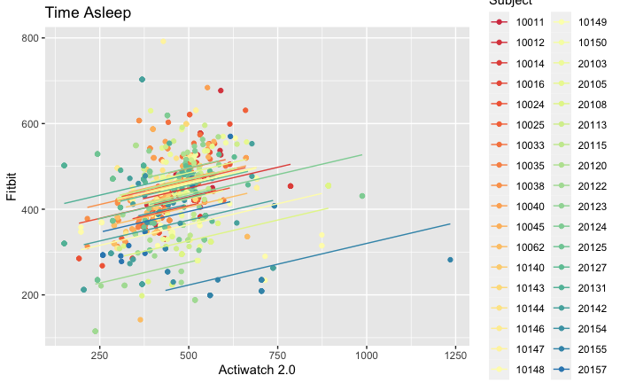

```r
my.rmc <- rmcorr(participant = subject, measure1 = time_asleep_act, measure2 = time_asleep_fit, dataset = df)

ggplot2::ggplot(df, ggplot2::aes(x = time_asleep_act, y = time_asleep_fit, group = factor(subject),
      color = factor(subject))) +
      ggplot2::geom_point(ggplot2::aes(colour = factor(subject))) +
      ggplot2::geom_line(ggplot2::aes(y = my.rmc$model$fitted.values), linetype = 1) + xlab('Actiwatch 2.0') + ylab('Fitbit') + ggtitle('Time Asleep') + scale_color_manual(values = getPalette(colourCount)) + labs(color = 'Subject') + ggsave(paste0(data_dir, 'CARE2021/figures/sleeptimermcorr.png'), height = 5, width = 8, dpi = 300)
```

#### Sleep Time: Cleaned Actiwatch data

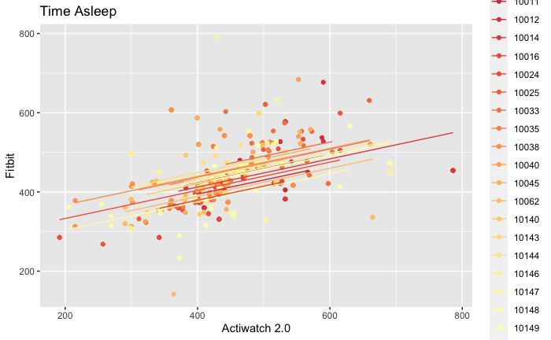

```r
my.rmc <- rmcorr(participant = subject, measure1 = time_asleep_cl, measure2 = time_asleep_fit, dataset = df[df$age_group == 1,], nreps=500)

ggplot2::ggplot(df[df$age_group == 1,], ggplot2::aes(x = time_asleep_cl, y = time_asleep_fit, group = factor(subject),
      color = factor(subject))) +
      ggplot2::geom_point(ggplot2::aes(colour = factor(subject))) +
      ggplot2::geom_line(ggplot2::aes(y = my.rmc$model$fitted.values), linetype = 1) + xlab('Actiwatch 2.0') + ylab('Fitbit') + ggtitle('Time Asleep') + scale_color_manual(values = getPalette(colourCount)) + labs(color = 'Subject')
```

```r
#raw
rmcorr(subject, time_asleep_act, time_asleep_fit, df)
```

```
Repeated measures correlation

r
0.2741189

degrees of freedom
721

p-value
6.280332e-14

95% confidence interval
0.2052111 0.3403224
```

```r
rmcorr(subject, time_asleep_act, time_asleep_fit, filter(df, handedness == 2))
```

```
Repeated measures correlation

r
0.2620646

degrees of freedom
671

p-value
4.950899e-12

95% confidence interval
0.190148 0.3311838
```

```r
rmcorr(subject, time_asleep_act, time_asleep_fit, filter(df, (actiwatch_arm == 1) & (handedness == 2)))
```

```
Repeated measures correlation

r
0.3734459

degrees of freedom
331

p-value
1.845944e-12

95% confidence interval
0.2767884 0.4626223
```

```r
rmcorr(subject, time_asleep_act, time_asleep_fit, filter(df, (actiwatch_arm == 2) & (handedness == 2)))
```

```
Repeated measures correlation

r
0.09787818

degrees of freedom
339

p-value
0.07105332

95% confidence interval
-0.008732025 0.2022883
```

```r
# manually cleaned
rmcorr(subject, time_asleep_cl, time_asleep_fit, df)
```

```
Repeated measures correlation

r
0.3072433

degrees of freedom
721

p-value
2.854961e-17

95% confidence interval
0.2396034 0.371915
```

```r
rmcorr(subject, time_asleep_cl, time_in_bed_fit, filter(df, handedness == 2))
```

```
Repeated measures correlation

r
0.291924

degrees of freedom
671

p-value
1.092137e-14

95% confidence interval
0.2211215 0.3596654
```

```r
rmcorr(subject, time_asleep_cl, time_in_bed_fit, filter(df, (actiwatch_arm == 1) & (handedness == 2)))
```

```
Repeated measures correlation

r
0.3609073

degrees of freedom
331

p-value
1.110282e-11

95% confidence interval
0.2633529 0.4511551
```

```r
rmcorr(subject, time_asleep_cl, time_in_bed_fit, filter(df, (actiwatch_arm == 2) & (handedness == 2)))
```

```
Repeated measures correlation

r
0.17582

degrees of freedom
339

p-value
0.001113192

95% confidence interval
0.07062353 0.2771487
```

```r
rmcorr(subject, time_asleep_act, time_in_bed_fit, df)
```

```
Repeated measures correlation

r
0.2704232

degrees of freedom
721

p-value
1.393078e-13

95% confidence interval
0.2013845 0.3367884
```

### Efficiency

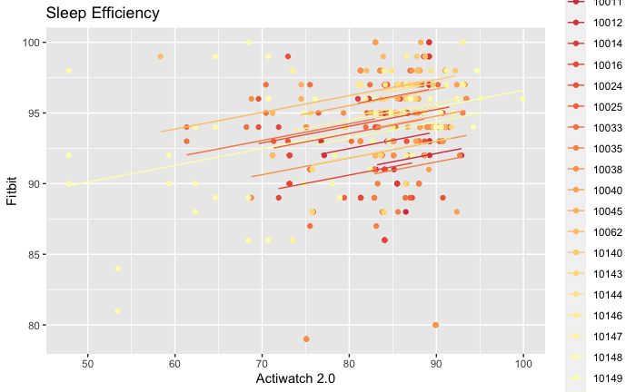

```r
my.rmc <- rmcorr(participant = subject, measure1 = efficiency_act, measure2 = efficiency_fit, dataset = df[df$age_group == 1,], nreps=500)

ggplot2::ggplot(df[df$age_group == 1,], ggplot2::aes(x = efficiency_act, y = efficiency_fit, group = factor(subject),
      color = factor(subject))) +
      ggplot2::geom_point(ggplot2::aes(colour = factor(subject))) +
      ggplot2::geom_line(ggplot2::aes(y = my.rmc$model$fitted.values), linetype = 1) + xlab('Actiwatch 2.0') + ylab('Fitbit') + ggtitle('Sleep Efficiency') + scale_color_manual(values = getPalette(colourCount)) + labs(color = 'Subject')
```

```r
rmcorr(subject, efficiency_act, efficiency_fit, df)
```

```
Repeated measures correlation

r
0.06349924

degrees of freedom
721

p-value
0.08797509

95% confidence interval
-0.009560122 0.1358843
```

### Next steps:

Need correlation value for each subject, then see how that’s related to measures of subjective sleep quality, handedness, arm assignment, percent watch off, beiwe, fitbit device

```r
corrdf <- df %>%
  group_by(subject) %>%
  summarize(sleep_time = cor(time_asleep_act, time_asleep_fit, method = 'spearman'), time_in_bed = cor(time_in_bed_act, time_in_bed_fit, method = 'spearman'))

head(corrdf)
```

| subject | sleep_time | time_in_bed |
| --- | --- | --- |
| 10011 | 0.4000000 | 0.40000000 |
| 10012 | 0.8157895 | 0.19956571 |
| 10014 | 0.6600561 | 0.04675139 |
| 10016 | 0.6488719 | 0.60885033 |
| 10024 | 0.8898746 | 0.90774932 |
| 10025 | 0.8747764 | 0.93202147 |

```r
NA
```

```r
dfcor <- merge(df, corrdf, by = 'subject')

head(dfcor)
```

|  | subject | joinid | subject_id | date.x | start_date_act | analysis_name_act | data_start_date_act | data_start_time_act | start_time_act | end_date_act | end_time_act | time_asleep_act | off_wrist_act | percent_off_wrist_act | total_ac_act | percent_invalid_sw_act | onset_latency_act | efficiency_act | wake_time_act | percent_wake_act | sleep_time_act | percent_sleep_act | percent_immobile_act | fragmentation_act | time_in_bed_act | start_date_cl | analysis_name_cl | data_start_date_cl | data_start_time_cl | … |
| --- | --- | --- | --- | --- | --- | --- | --- | --- | --- | --- | --- | --- | --- | --- | --- | --- | --- | --- | --- | --- | --- | --- | --- | --- | --- | --- | --- | --- | --- | --- |
| 1 | 10011 | 10011_2019-11-03 | 10011 | 2019-11-03 | 11/2/2019 | New Analysis | 10/24/2019 | 16:30:00 | 9:37:30 PM | 11/3/2019 | 7:04:00 AM | 566.5 | NaN | NaN | 4999 | 0 | 13.5 | 92.89 | 24.0 | 4.24 | 542.5 | 95.76 | 96.03 | 3.97 | 584.0 | 11/2/2019 | New Analysis | 10/24/2019 | 16:30:00 | … |
| 2 | 10011 | 10011_2019-11-04 | 10011 | 2019-11-04 | 11/3/2019 | New Analysis | 10/24/2019 | 16:30:00 | 11:00:00 PM | 11/4/2019 | 6:44:00 AM | 464.0 | NaN | NaN | 6253 | 0 | 0.0 | 86.49 | 44.5 | 9.59 | 419.5 | 90.41 | 92.46 | 18.07 | 485.0 | 11/3/2019 | New Analysis | 10/24/2019 | 16:30:00 | … |
| 3 | 10011 | 10011_2019-11-05 | 10011 | 2019-11-05 | 11/4/2019 | New Analysis | 10/24/2019 | 16:30:00 | 10:15:00 PM | 11/5/2019 | 7:07:30 AM | 532.5 | NaN | NaN | 10659 | 0 | 14.5 | 83.20 | 77.0 | 14.46 | 455.5 | 85.54 | 89.11 | 26.41 | 547.5 | 11/4/2019 | New Analysis | 10/24/2019 | 16:30:00 | … |
| 4 | 10011 | 10011_2019-11-06 | 10011 | 2019-11-06 | 11/5/2019 | New Analysis | 10/24/2019 | 16:30:00 | 11:56:30 PM | 11/6/2019 | 6:39:00 AM | 402.5 | NaN | NaN | 5888 | 0 | 28.0 | 84.34 | 39.0 | 9.69 | 363.5 | 90.31 | 92.05 | 14.01 | 431.0 | 11/5/2019 | New Analysis | 10/24/2019 | 16:30:00 | … |
| 5 | 10012 | 10012_2019-10-19 | 10012 | 2019-10-19 | 10/19/2019 | New Analysis | 10/18/2019 | 15:30:00 | 1:57:00 AM | 10/19/2019 | 11:47:00 AM | 590.0 | NaN | NaN | 8410 | 0 | 4.0 | 88.56 | 63.5 | 10.76 | 526.5 | 89.24 | 87.20 | 20.94 | 594.5 | 10/19/2019 | Manual | 10/18/2019 | 15:30:00 | … |
| 6 | 10012 | 10012_2019-10-19 | 10012 | 2019-10-19 | 10/19/2019 | New Analysis | 10/18/2019 | 15:30:00 | 1:57:00 AM | 10/19/2019 | 11:47:00 AM | 590.0 | NaN | NaN | 8410 | 0 | 4.0 | 88.56 | 63.5 | 10.76 | 526.5 | 89.24 | 87.20 | 20.94 | 594.5 | 10/19/2019 | Manual | 10/18/2019 | 15:30:00 | … |

```r
NA
```

```r
unique(dfcor$subject[dfcor$time_in_bed < 0.5])
```

```
 [1] 10011 10012 10014 10033 10038 10040 10045 10062 10140 10146 10147 10148 10149 20103 20105 20108 20113 20115
[19] 20120 20122 20123 20124 20125 20127 20131 20142 20154 20155 20157
```

```r
length(unique(dfcor$subject[dfcor$time_in_bed < 0.5]))
```

```
[1] 29
```

```r
unique(dfcor$subject[dfcor$sleep_time < 0.5])
```

```
 [1] 10011 10033 10038 10045 10140 10147 10148 10149 20103 20105 20113 20115 20120 20122 20123 20124 20125 20131
[19] 20142 20154 20155
```

```r
length(unique(dfcor$subject[dfcor$sleep_time < 0.5]))
```

```
[1] 21
```

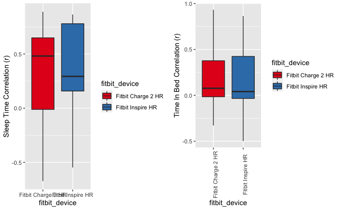

```r
require(gridExtra)

plot1 <- dfcor %>%
  ggplot() +
  geom_boxplot(aes(x = fitbit_device, y = sleep_time, fill = fitbit_device, group = fitbit_device)) +
  ylab('Sleep Time Correlation (r)') +
  scale_fill_brewer(palette = 'Set1')

plot2 <- dfcor %>%
  ggplot() +
  geom_boxplot(aes(x = fitbit_device, y = time_in_bed, fill = fitbit_device, group = fitbit_device)) +
  ylab('Time In Bed Correlation (r)') +
  scale_fill_brewer(palette = 'Set1') + theme(axis.text.x = element_text(angle = 90))

grid.arrange(plot1, plot2, ncol=2)
```

[figure not shown]

[figure not shown]

```r
summary(lm(time_in_bed_act ~ time_in_bed_fit + dominant_assignment, data = df_means))
```

```
Call:
lm(formula = time_in_bed_act ~ time_in_bed_fit + dominant_assignment,
    data = df_means)

Residuals:
     Min       1Q   Median       3Q      Max
-113.165  -54.558    3.155   31.991  179.772

Coefficients:
                                Estimate Std. Error t value Pr(>|t|)
(Intercept)                     571.5440    95.8090   5.965 1.07e-06 ***
time_in_bed_fit                  -0.1331     0.2043  -0.651    0.519
dominant_assignmentNon-Dominant   4.7718    23.9942   0.199    0.844
---
Signif. codes:  0 ‘***’ 0.001 ‘**’ 0.01 ‘*’ 0.05 ‘.’ 0.1 ‘ ’ 1

Residual standard error: 71.18 on 33 degrees of freedom
Multiple R-squared:  0.0152,    Adjusted R-squared:  -0.04448
F-statistic: 0.2547 on 2 and 33 DF,  p-value: 0.7766
```

```r
dfcor$age_group <- factor(dfcor$age_group, labels = c("Young Adults", "Older Adults"))

plot1 <- dfcor %>%
  ggplot() +
  geom_boxplot(aes(x = age_group, y = sleep_time, fill = age_group, group = age_group)) +
  ylab('Sleep Time Correlation (r)') +
  scale_fill_brewer(palette = 'Set1') + xlab("Age Group")

plot2 <- dfcor %>%
  ggplot() +
  geom_boxplot(aes(x = age_group, y = time_in_bed, fill = age_group, group = age_group)) +
  ylab('Time In Bed Correlation (r)') +
  scale_fill_brewer(palette = 'Set1') + xlab("Age Group")

pnew <- arrangeGrob(plot1, plot2, ncol=2)
ggsave("~/Desktop/agegroup.png", pnew, height = 5, width = 10, units = "in")
```

## Bland Altman plots

About the package: [blandr](https://cran.r-project.org/web/packages/blandr/vignettes/introduction.html) Interpretation: [Statology](https://www.statology.org/bland-altman-plot/)

e.g.

The average of the values in the Difference column turns out to be 0.5. (middle line) The standard deviation of values in the Difference column turns out to be 1.235. The upper and lower limits of the confidence interval for the average difference can be calculated as:

Upper Limit: x + 1.96*s = 0.5 + 1.96*1.235 = 2.92 Lower Limit: x – 1.96*s = 0.5 – 1.96*1.235 = -1.92

On average, instrument A weighs frogs to be 0.5 grams heavier than instrument B. 95% of the differences in weight between the two instruments are expected to fall in the range of -1.92 grams and 2.92 grams.

First look at which device may be under or over estimating - Fitbit underestimating sleep time and time in bed

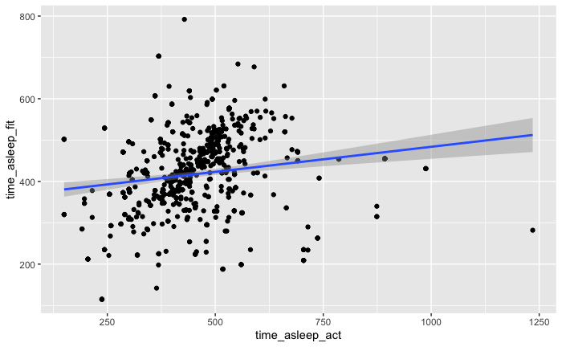

```r
# fitbit underestimating sleep time
df %>%
  ggplot(aes(x = time_asleep_act, y = time_asleep_fit)) +
  geom_point() +
  stat_smooth(method = "lm")
```

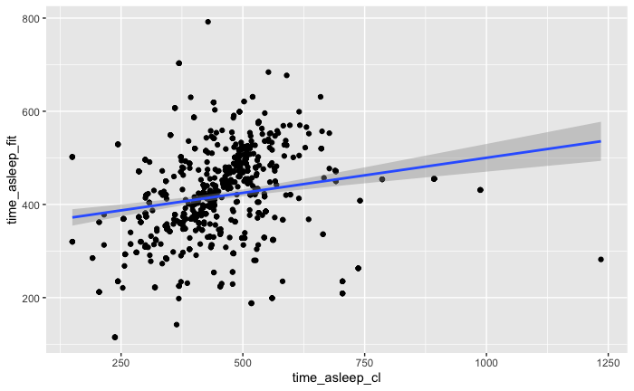

```r
df %>%
  ggplot(aes(x = time_asleep_cl, y = time_asleep_fit)) +
  geom_point() +
  stat_smooth(method = "lm")
```

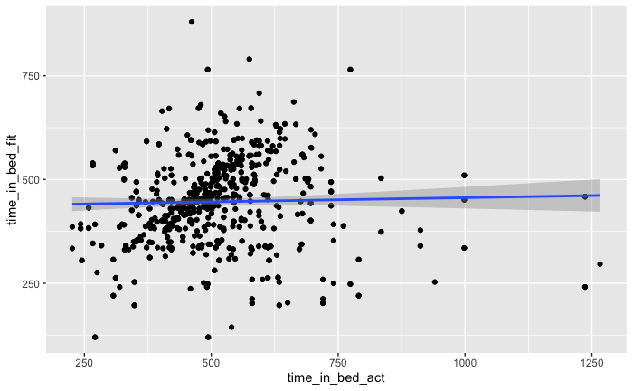

```r
#fitbit underestimating time in bed
df %>%
  ggplot(aes(x = time_in_bed_act, y = time_in_bed_fit)) +
  geom_point() +
  stat_smooth(method = "lm")
```

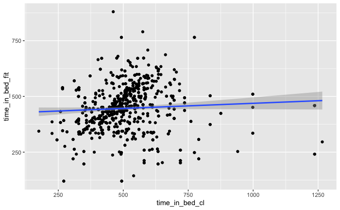

```r
df %>%
  ggplot(aes(x = time_in_bed_cl, y = time_in_bed_fit)) +
  geom_point() +
  stat_smooth(method = "lm")
```

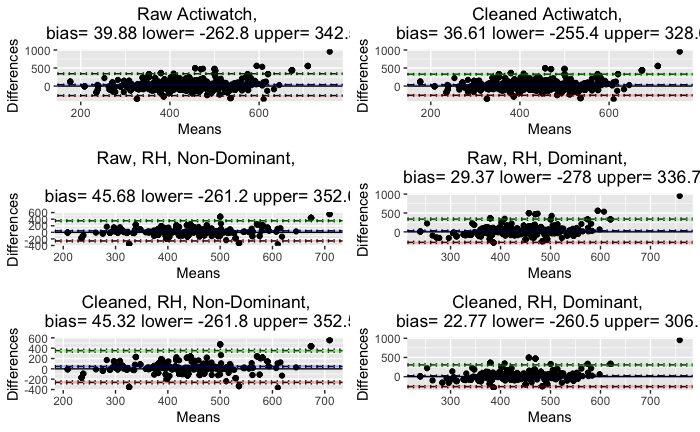

```r
library(blandr)

df.stats <- blandr.statistics(df$time_asleep_act , df$time_asleep_fit)
p1 <- blandr.draw(df$time_asleep_act , df$time_asleep_fit ) + ggtitle(paste("Raw Actiwatch, \n bias=", signif(df.stats$bias, 4), "lower=", signif(df.stats$lowerLOA, 4), "upper=", signif(df.stats$upperLOA, 4)))

df.stats <- blandr.statistics(df$time_asleep_cl , df$time_asleep_fit)
p2 <- blandr.draw(df$time_asleep_cl , df$time_asleep_fit) + ggtitle(paste("Cleaned Actiwatch, \n bias=", signif(df.stats$bias, 4), "lower=", signif(df.stats$lowerLOA, 4), "upper=", signif(df.stats$upperLOA, 4)))

df.stats <- blandr.statistics(df$time_asleep_act[(df$actiwatch_arm == 1) & (df$handedness == 2)] , df$time_asleep_fit[(df$actiwatch_arm == 1) & (df$handedness == 2)])
p3 <- blandr.draw(df$time_asleep_act[(df$actiwatch_arm == 1) & (df$handedness == 2)] , df$time_asleep_fit[(df$actiwatch_arm == 1) & (df$handedness == 2)]) + ggtitle(paste("Raw, RH, Non-Dominant, \n \n bias=", signif(df.stats$bias, 4), "lower=", signif(df.stats$lowerLOA, 4), "upper=", signif(df.stats$upperLOA, 4)))

df.stats <- blandr.statistics(df$time_asleep_act[(df$actiwatch_arm == 2) & (df$handedness == 2)] , df$time_asleep_fit[(df$actiwatch_arm == 2) & (df$handedness == 2)])
p4 <- blandr.draw(df$time_asleep_act[(df$actiwatch_arm == 2) & (df$handedness == 2)] , df$time_asleep_fit[(df$actiwatch_arm == 2) & (df$handedness == 2)]) + ggtitle(paste("Raw, RH, Dominant, \n bias=", signif(df.stats$bias, 4), "lower=", signif(df.stats$lowerLOA, 4), "upper=", signif(df.stats$upperLOA, 4)))

df.stats <- blandr.statistics(df$time_asleep_cl[(df$actiwatch_arm == 1) & (df$handedness == 2)] , df$time_asleep_fit[(df$actiwatch_arm == 1) & (df$handedness == 2)])
p5 <- blandr.draw(df$time_asleep_cl[(df$actiwatch_arm == 1) & (df$handedness == 2)] , df$time_asleep_fit[(df$actiwatch_arm == 1) & (df$handedness == 2)]) + ggtitle(paste("Cleaned, RH, Non-Dominant, \n bias=", signif(df.stats$bias, 4), "lower=", signif(df.stats$lowerLOA, 4), "upper=", signif(df.stats$upperLOA, 4)))

df.stats <- blandr.statistics(df$time_asleep_cl[(df$actiwatch_arm == 2) & (df$handedness == 2)] , df$time_asleep_fit[(df$actiwatch_arm == 2) & (df$handedness == 2)])
p6 <- blandr.draw(df$time_asleep_cl[(df$actiwatch_arm == 2) & (df$handedness == 2)] , df$time_asleep_fit[(df$actiwatch_arm == 2) & (df$handedness == 2)]) + ggtitle(paste("Cleaned, RH, Dominant, \n bias=", signif(df.stats$bias, 4), "lower=", signif(df.stats$lowerLOA, 4), "upper=", signif(df.stats$upperLOA, 4)))

gridExtra::grid.arrange(p1, p2, p3, p4, p5, p6, nrow=3, ncol=2)
```

```r
pall <- gridExtra::arrangeGrob(p1, p2, p3, p4, p5, p6, nrow=3, ncol=2)
```

[output not shown]

```r
ggsave("~/Box/CogNeuroLab/Wearables/results/time_asleep_bland_altman.png", pall, scale = 1.5, dpi = 300)
```

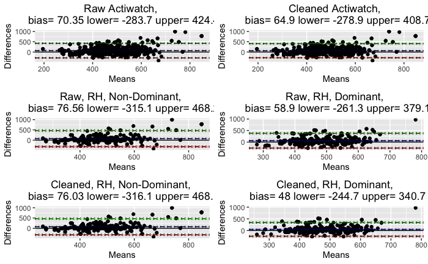

```r
library(blandr)

df.stats <- blandr.statistics(df$time_in_bed_act , df$time_in_bed_fit)
p1 <- blandr.draw(df$time_in_bed_act , df$time_in_bed_fit ) + ggtitle(paste("Raw Actiwatch, \n bias=", signif(df.stats$bias, 4), "lower=", signif(df.stats$lowerLOA, 4), "upper=", signif(df.stats$upperLOA, 4)))

df.stats <- blandr.statistics(df$time_in_bed_cl , df$time_in_bed_fit)
p2 <- blandr.draw(df$time_in_bed_cl , df$time_in_bed_fit) + ggtitle(paste("Cleaned Actiwatch, \n bias=", signif(df.stats$bias, 4), "lower=", signif(df.stats$lowerLOA, 4), "upper=", signif(df.stats$upperLOA, 4)))

df.stats <- blandr.statistics(df$time_in_bed_act[(df$actiwatch_arm == 1) & (df$handedness == 2)] , df$time_in_bed_fit[(df$actiwatch_arm == 1) & (df$handedness == 2)])
p3 <- blandr.draw(df$time_in_bed_act[(df$actiwatch_arm == 1) & (df$handedness == 2)] , df$time_in_bed_fit[(df$actiwatch_arm == 1) & (df$handedness == 2)]) + ggtitle(paste("Raw, RH, Non-Dominant, \n bias=", signif(df.stats$bias, 4), "lower=", signif(df.stats$lowerLOA, 4), "upper=", signif(df.stats$upperLOA, 4)))

df.stats <- blandr.statistics(df$time_in_bed_act[(df$actiwatch_arm == 2) & (df$handedness == 2)] , df$time_in_bed_fit[(df$actiwatch_arm == 2) & (df$handedness == 2)])
p4 <- blandr.draw(df$time_in_bed_act[(df$actiwatch_arm == 2) & (df$handedness == 2)] , df$time_in_bed_fit[(df$actiwatch_arm == 2) & (df$handedness == 2)]) + ggtitle(paste("Raw, RH, Dominant, \n bias=", signif(df.stats$bias, 4), "lower=", signif(df.stats$lowerLOA, 4), "upper=", signif(df.stats$upperLOA, 4)))

df.stats <- blandr.statistics(df$time_in_bed_cl[(df$actiwatch_arm == 1) & (df$handedness == 2)] , df$time_in_bed_fit[(df$actiwatch_arm == 1) & (df$handedness == 2)])
p5 <- blandr.draw(df$time_in_bed_cl[(df$actiwatch_arm == 1) & (df$handedness == 2)] , df$time_in_bed_fit[(df$actiwatch_arm == 1) & (df$handedness == 2)]) + ggtitle(paste("Cleaned, RH, Non-Dominant, \n bias=", signif(df.stats$bias, 4), "lower=", signif(df.stats$lowerLOA, 4), "upper=", signif(df.stats$upperLOA, 4)))

df.stats <- blandr.statistics(df$time_in_bed_cl[(df$actiwatch_arm == 2) & (df$handedness == 2)] , df$time_in_bed_fit[(df$actiwatch_arm == 2) & (df$handedness == 2)])
p6 <- blandr.draw(df$time_in_bed_cl[(df$actiwatch_arm == 2) & (df$handedness == 2)] , df$time_in_bed_fit[(df$actiwatch_arm == 2) & (df$handedness == 2)]) + ggtitle(paste("Cleaned, RH, Dominant, \n bias=", signif(df.stats$bias, 4), "lower=", signif(df.stats$lowerLOA, 4), "upper=", signif(df.stats$upperLOA, 4)))

gridExtra::grid.arrange(p1, p2, p3, p4, p5, p6, nrow=3, ncol=2)
```

```r
pall <- gridExtra::arrangeGrob(p1, p2, p3, p4, p5, p6, nrow=3, ncol=2)
```

[output not shown]

```r
ggsave("~/Box/CogNeuroLab/Wearables/results/time_in_bed_bland_altman.png", pall, scale = 1.5, dpi = 300)
```